# Practical Machine Learning Course Project

Edward Kuns

Sunday, April 26, 2015

## Abstract

In this exercise, I ran various machine learning algorithms on a data measuring study participants performing bicep curls. The goal is to accurately predict the specific activity being done. This is a classification machine learning problem. With a random forest model, I was able to achieve better than 99% accuracy.

## Data Set Description

The data set is from:

Velloso, E.; Bulling, A.; Gellersen, H.; Ugulino, W.; Fuks, H. Qualitative Activity Recognition of Weight Lifting Exercises. Proceedings of 4th International Conference in Cooperation with SIGCHI (Augmented Human ’13) . Stuttgart, Germany: ACM SIGCHI, 2013.

The data set was gathered from the web site http://groupware.les.inf.puc-rio.br/har – a collection of Human Activity Recognition (HAR) data sets and publications which itself may be cited as follows:

Ugulino, W.; Cardador, D.; Vega, K.; Velloso, E.; Milidiu, R.; Fuks, H. Wearable Computing: Accelerometers’ Data Classification of Body Postures and Movements. Proceedings of 21st Brazilian Symposium on Artificial Intelligence. Advances in Artificial Intelligence - SBIA 2012. In: Lecture Notes in Computer Science. , pp. 52-61. Curitiba, PR: Springer Berlin / Heidelberg, 2012. ISBN 978-3-642-34458-9. DOI: 10.1007/978-3-642-34459-6_6.

In the experiment, the participants were asked to do ten bicep curls repetitions in one of five different ways:

- A - With proper form
- B - Throwing elbows to the front
- C - Lifting the dumbbell only half way
- D - Lowering the dumbbell only half way
- E - Throwing hips to the front

The participants did the bicep curls with four instruments attached. Each instrument is a “9 degrees of freedom Razor inertial measurement unit (IMU)” providing three-axis accelerameter, gyroscope, and magnetometer data at a rate of 45 Hz. The four IMUs were mounted on the user’s glove, arm band, lumbar belt, and on the dumbbell.

After the data was acquired from the participants doing the exercises, the original authors did a fair amount of post-processing was done on the data. I don’t describe the post-processing because I discarded all of the features it created. Those additional features were inappropriate for the kinds of machine learning algorithms I was using because I was not treating the data as a time series. In fact, you don’t need to treat this data as a time series to accurately predict which form of bicep curls is being done.

## Data Selection

I decided to try a variety of different models to see how they perform. After some exploratory analysis, I realized that the post-processing columns mostly contain `NA` values, or the literal value “`#DIV/0!`”. Both values were treated as NA when importing the data. These columns contain over 95% NA values and are not useful if you don’t treat the data as a time series.

To avoid the possibility of overtraining/mistraining, I discarded the timestamp and window features. They may correlate with the outcome variable, but won’t be useful for prediction when using data collected at another time. The user name also shouldn’t have anything to do with predicting which version of the bicep curls was being done. Thus, in the end, I only included the 52 original data measurements for my machine learning sample. The 52 features are broken down into four sets of 13 features, where the four sets are belt (lumbar belt), arm (arm band), dumbbell, and forearm (glove).

The 13 features for each are:

- 3d gyroscope: roll, pitch, yaw, plus gyros_belt_x, gyros_belt_y, gyros_belt_z
- 3d accelerameter: accel_belt_x, accel_belt_y, accel_belt_z, and total_accel_belt
- 3d magnetometer: magnet_belt_x, magnet_belt_y, magnet_belt_z

## Model Selection

I selected six different models to try on this data set. I selected random forest because the lectures mentioned this as a good model to use for classification problems. The remaining models that were selected are all supported by the caret package. I wanted to try a variety of models. The only requirement is that the model be suitable for classification problems. The models selected are:

- Random Forest
- K Nearest Neighbor
- Classification and Regression Trees (CART)
- Stochastic Gradient Boosting
- Support Vector Machines w/ Linear Kernel
- Linear Discriminant Analysis

For all models, the data was partitioned into a training and a test data set in a 60/40 split so the out-of-sample error rate can be measured on a test data set.

There is an additional sample of 20 events. This sample is not used in this analysis. However, the best model produced in this analysis is used to predict the method of bicep curl performed for each of those events and those predictions were separately submitted for grading.

### Random Forest Fit Tuning

With random forests, Caret, by default, fits 500 trees with three different values of the tuning parameter mtry. In order to decrease the running time of the machine learning algorithm, I decided to investigate whether this was necessary. First, I ran the normal random forest algorithm, not via the caret package, with 100 trees:

```r
# Look at a quick-and-dirty random forest so we can find a reasonble
# number of trees to speed it up the ultimate model training
fitRandomForest <- randomForest(as.factor(classe) ~ ., data=training, ntree=100)
```

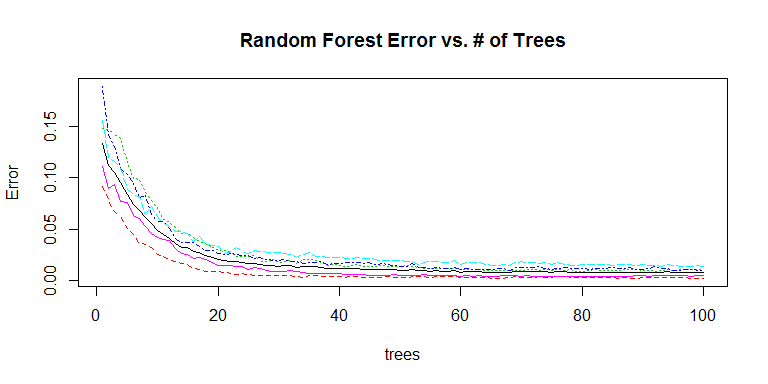

**Figure 1**: Choosing a value for the number of trees. Notice that the error rapidly decreases, reaching its approximate minimal value between around 20-40.

```r
# Look at OOB error vs number of trees
plot(fitRandomForest, main="Random Forest Error vs. # of Trees")
```

Given the increase in computing time as the number of trees increases, and contrasting this with the minimal gain in accuracy above about 40, I set the number of trees to be 40. Exploratory analysis also showed that it was reasonable and safe to set the mtry parameter to half the number of features, that doing so did not decrease the quality of the fit. Since caret, by default, will try three different values of mtry, setting an explicit value speeds the fit up by a factor of three.

Finally, prox=TRUE (e.g., `proximity=TRUE`) was passed to the random forest algorithm so that it will keep additional data during its processing.

### K Nearest Neighbor Tuning

For the K Nearest Neighbor model, the tune length was increased from the default of 3 up to 20. This allowed this model to explore a larger set of values of the parameters it was fitting.

### Stochastic Gradient Boosting Tuning

Verbose was set to false for Stochastic Gradient Boosting to quiet the flood of diagnostic output that would otherwise be seen.

### Cross-validation

The fits for all models use 5 rounds of repeated cross validation.

## Results

After each fit was trained, the confusion matrix was generated using that fit on the training sample (to look at in-sample accuracy) and on the test sample (to look at the out-of-sample accuracy). The “accuracy” measurement simply means the percentage of correct predictions – true positives and true negatives. The error rate is therefore 1 - accuracy (or 100% - accuracy as a percentage).

The out-of-sample accuracy of the six models varies widely, from almost 50% accuracy to over 99% accuracy.

Classification and regression trees performed by far the worst, but several models were so-so at best. Only two of the models performed better than 95% accuracy: random forest and stochastic gradient boosting. The random forest model was the clear winner, with better than 99% accuracy. In fact, the random forest model achieved a 100% accuracy on the training sample! This suggests the possibility of overfitting, but the model was also highly accurate on the test sample. Therefore, I am not worried about overfitting in this case.

Notice, as expected, that in almost all cases, the in-sample error rate is lower than the out-of-sample error rate.

The running time in seconds for each model fit is also shown. The fastest model was about 35 times faster than the slowest! Interestingly, the fastest models to train were also the least accurate, as a group. This analysis was run using the `doParallel` library on a dual quad-core hyperthreaded system with 48 GB RAM. It took *significantly* longer when run in single-threaded fashion on a normal laptop.

| Model | Accuracy (%) | Out of Sample Error (%) | In Sample Error (%) | Running Time (sec) |
| --- | --- | --- | --- | --- |
| Random Forest | 99.1 | 0.9 | 0 | 405.67 |
| K Nearest Neighbor | 89.3 | 10.7 | 5.5 | 478.77 |
| Classification and Regression Trees | 49.6 | 50.4 | 50.5 | 29.76 |
| Stochastic Gradient Boosting | 95.9 | 4.1 | 2.6 | 440.86 |
| Support Vector Machines w/ Linear Kernel | 78.1 | 21.9 | 20.8 | 182.6 |
| Linear Discriminant Analysis | 70.2 | 29.8 | 29.4 | 13.75 |

**Figure 2**. Comparing model Accuracy, in and out of sample error rate, and running time. The accuracy and out-of-sample error are measured on the test sample. The in-sample error, of course, is measured on the training sample.

Since the random forest was the most accurate fit, it’s interesting to see which features ended up being the most significant.

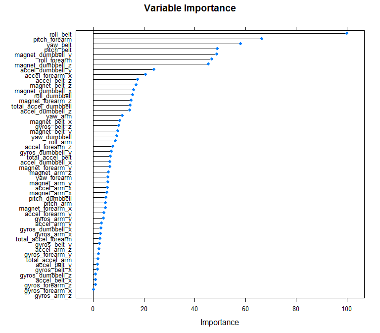

**Figure 3**: Variable Importance of the features for the random forest model. The gyro features are mostly at the bottom of the plot. On the other hand, roll, pitch, and yaw for the belt were three of the top four features.

```r
plot(varImp(model1), main = "Variable Importance", top = 52)
```

Finally, since caret automatically does cross validation (unless you specifically disable it), it is interesting to compare the cross validation that is done during the fitting process (and thus within the training sample) with the error measured on the test sample.

It turns out that the cross validated measurement of the out-of-sample error matches the actual measured out-of-sample error very nicely, for all models.

| Model | Out of Sample Error (%) | CV Estimate of OOS Error (%) | Abs(Difference) |
| --- | --- | --- | --- |
| Random Forest | 0.9 | 1.1 | 0.25 |
| K Nearest Neighbor | 10.7 | 11.4 | 0.65 |
| Classification and Regression Trees | 50.4 | 51.3 | 0.94 |
| Stochastic Gradient Boosting | 4.1 | 4 | 0.08 |
| Support Vector Machines with Linear Kernel | 21.9 | 21.8 | 0.13 |
| Linear Discriminant Analysis | 29.8 | 29.8 | 0.03 |

**Figure 4**. Comparing cross validation to validation by the test sample. Here, I compare the error rates, which is simply 100% - the accuracy (as a percentage). The chart lists the absolutely value of the difference only because for the purpose of this comparison it doesn’t matter which one is larger than the other.

In all cases, the cross validation measurement of the out-of-sample error rate was within 1% of the out-of-sample error rate as measured in the test sample.

## Conclusion

Using a random forest model, it is possible to get an excellent fit, meaning it is possible to accurately predict the exercise method using just the 52 features measured from the sensors or trivially computed from the sensor measurements. It is not necessary to treat the data as a time series to make accurate predictions. With this specific data (bicep curls with this set of sensors), the random forest model is the best of the six different models that were tried, achieving greater than 99% accuracy.

The accuracy and out-of-sample error rate were measured on a test sample, although this measurement agreed well with the cross-validated measurement made by caret. Thus, the random forest model out-of-sample error rate is expected to be less than 1%, as it was measured to be less than 1% on the test data sample.

Note that the random forest model tuned in this analysis was used to predict the 20 samples provided for the “Course Project: Submission” portion, and all 20 were correctly predicted.

## Appendix: Code for the Analysis

All of the code used for the fitting is shown below.

```r
library(caret)
library(randomForest)

# The data files are pre-downloaded and saved in the "data" folder
trainingFile <- "data/pml-training.csv"
testingFile <- "data/pml-testing.csv"

fullTraining <- read.csv(trainingFile, na.strings=c("NA", "#DIV/0!"))
submission <- read.csv(testingFile, na.strings=c("NA", "#DIV/0!"))

set.seed(27182818)
inTrain <- createDataPartition(y=fullTraining$classe,p=0.6,list=FALSE)

cols <- grep("^(roll|pitch|yaw|total_accel|gyros|accel|magnet)_(belt|arm|forearm|dumbbell)(_(x|y|z))?",
             colnames(fullTraining), perl=TRUE, value=TRUE)
training <- fullTraining[inTrain, c("classe", cols)]
testing <- fullTraining[-inTrain, c("classe", cols)]

# Set seeds for repeatable runs using parallel computation.
# 10xrepeated CV for 5 repeats == 50, so we need 50+1 == 51 sets of seeds in our vector.
# If we have too many seeds, it's not a problem.  The extras are ignored.
seeds <- vector(mode = "list", length = 51)
for(i in 1:50) seeds[[i]] <- sample.int(999999999, 25)

# For the last model:
seeds[[51]] <- sample.int(999999999, 1)

# Use the same cross-validation folding for most fits
trControl <- trainControl(method="repeatedcv", repeats=5, seeds=seeds, allowParallel=TRUE)

library(doParallel)
cluster <- makeCluster(detectCores())
registerDoParallel(cluster)

# Random Forest
tGrid <- data.frame(mtry=length(cols)/2) # Factor of 3 speed up by providing a specific value to use
model1Time <- system.time(model1 <- train(as.factor(classe) ~ ., data=training, method="rf",
                                          ntree=40, prox=TRUE, tuneGrid=tGrid, trControl=trControl))
# in-sample error
model1_ISError <- confusionMatrix(predict(model1, training), training$classe)
# out-of-sample
model1_OOSError <- confusionMatrix(predict(model1, testing), testing$classe)

# k nearest neighbors
model2Time <- system.time(model2 <- train(classe ~ ., data=training, method="knn", tuneLength=20,
                                          trControl=trControl))
# in-sample error
model2_ISError <- confusionMatrix(predict(model2, training), training$classe)
# out-of-sample
model2_OOSError <- confusionMatrix(predict(model2, testing), testing$classe)

# CART
model3Time <- system.time(model3 <- train(as.factor(classe) ~ ., data=training, method="rpart", trControl=trControl))
# in-sample error
model3_ISError <- confusionMatrix(predict(model3, training), training$classe)
# out-of-sample
model3_OOSError <- confusionMatrix(predict(model3, testing), testing$classe)

# Stochastic Gradient Boosting
model4Time <- system.time(model4 <- train(classe ~ ., data=training, method="gbm", verbose=FALSE, trControl=trControl))
# in-sample error
model4_ISError <- confusionMatrix(predict(model4, training), training$classe)
# out-of-sample
model4_OOSError <- confusionMatrix(predict(model4, testing), testing$classe)

# Support Vector Machines with Linear Kernel
model5Time <- system.time(model5 <- train(as.factor(classe) ~ ., data=training, method="svmLinear", trControl=trControl))
# in-sample error
model5_ISError <- confusionMatrix(predict(model5, training), training$classe)
# out-of-sample
model5_OOSError <- confusionMatrix(predict(model5, testing), testing$classe)

# Linear Discriminant Analysis
model6Time <- system.time(model6 <- train(as.factor(classe) ~ ., data=training, method="lda", trControl=trControl))
# in-sample error
model6_ISError <- confusionMatrix(predict(model6, training), training$classe)
# out-of-sample
model6_OOSError <- confusionMatrix(predict(model6, testing), testing$classe)

stopCluster(cluster)
registerDoSEQ()
```